# General Tasks

31 August 2019

**Group members:**

Philipp Herpich, Marina Matthaiou, Daniel Schewitz, Tatjana Stefanie Spanehl, Anastasios Tsigkros

In addition to the case study, some general tasks should also be worked on. The general tasks described below are divided into six parts. Their solutions and associated code can be seen in more detail.

## Packages

```r
if( !require(tidyverse)){
  install.packages("tidyverse")
}
library(tidyverse)

if( !require(readr)){
  install.packages("readr")
}
library(readr)

if(!require(base)){
  install.packages("base")
}
library(base)

if(!require(ggplot2)){
  install.packages("ggplot2")
}
library(ggplot2)

if(!require(stringr)){
  install.packages("stringr")
}
library(stringr)
```

## Task 1

After the packages have been included, they are read in by the read.delim () and with read.csv functions. At the same time, dates are formatted, so that we can work with them more easily.

```r
component_K7 <- read.delim(paste("Data/Logistikverzug/Komponente_K7.csv", sep = ""), ";", header = TRUE)[, (2:3)]
component_K7$Produktionsdatum <- as.Date(component_K7$Produktionsdatum)


Verzug_K7 <- read.csv("Data/Logistikverzug/Logistikverzug_K7.csv", sep = ";", header = TRUE)[, (2:3)]
Verzug_K7$Wareneingang <- as.Date(Verzug_K7$Wareneingang, format = "%d.%m.%Y")
```

The data records are linked with full_join (). In addition, mutate () creates a new column named “delay”, which contains the difference between the goods receipt and the production date at the supplier. In order to be able to determine the distribution of the logistics delay, they are first converted into an integer using as.numeric.

```r
Logistics_delay <- full_join(component_K7, Verzug_K7, by = "IDNummer")

Logistics_delay <- Logistics_delay %>%
  mutate(delay = Wareneingang-Produktionsdatum)
Logistics_delay$delay <- as.numeric(Logistics_delay$delay)
head(Logistics_delay)
```

```
##        IDNummer Produktionsdatum Wareneingang delay
## 1 K7-114-1142-1       2008-11-12   2008-11-17     5
## 2 K7-114-1142-2       2008-11-12   2008-11-17     5
## 3 K7-114-1142-3       2008-11-13   2008-11-18     5
## 4 K7-114-1142-4       2008-11-13   2008-11-18     5
## 5 K7-114-1142-5       2008-11-13   2008-11-17     4
## 6 K7-114-1142-6       2008-11-13   2008-11-19     6
```

### Distribution of logistics delay

**How is the logistics delay distributed? Justify your selection and briefly describe your approach.**

By having a look at the summary you can see that the mean value is 5.08. By having a look at the 1st Qu. and 3.Qu. you can find out that the distributon is rather even around the median. The difference between the 1st Qu. and the min is 2 while the difference between the Max and the 3rd Qu. is 7. This is an indicator for the fact it is a distribution with a steap left side. We can concude that our distribution is not a normal one, but a logarithmic normal(lognormal).

```r
summary(Logistics_delay)
```

```
##                IDNummer      Produktionsdatum      Wareneingang
##  K7-113-1132-1     :     1   Min.   :2008-11-12   Min.   :2008-11-17
##  K7-113-1132-10    :     1   1st Qu.:2010-11-14   1st Qu.:2010-11-19
##  K7-113-1132-100   :     1   Median :2012-11-12   Median :2012-11-17
##  K7-113-1132-1000  :     1   Mean   :2012-11-12   Mean   :2012-11-17
##  K7-113-1132-10000 :     1   3rd Qu.:2014-11-12   3rd Qu.:2014-11-17
##  K7-113-1132-100000:     1   Max.   :2016-11-13   Max.   :2016-11-20
##  (Other)           :306484
##      delay
##  Min.   : 2.00
##  1st Qu.: 4.00
##  Median : 5.00
##  Mean   : 5.08
##  3rd Qu.: 6.00
##  Max.   :13.00
##
```

### Goods receipt and goods exited

**What is the minimum/maximum time between delivering and receiving goods? Determine the mean of the logistics delay**

```r
maximum_time <- max(Logistics_delay$delay)
maximum_time
```

```
## [1] 13
```

```r
mean_delay <- mean(Logistics_delay$delay)
mean_delay
```

```
## [1] 5.080437
```

### Visualization of the distribution

**Visualize the distribution in an appropriate way.**

For the visualization of the distribution we chose a histogram.

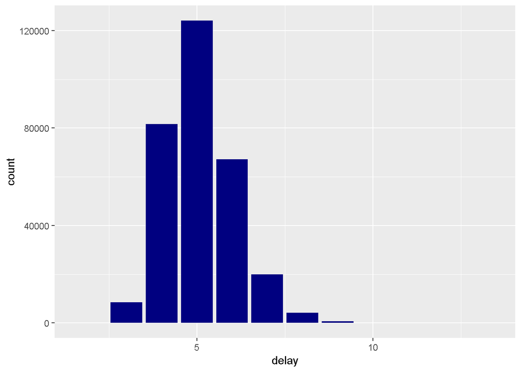

```r
ggplot(Logistics_delay,aes(delay)) +
  geom_bar(fill = "navy")
```

## Task 2

**Why does it make sense to store the available data in separate files instead of saving everything in a huge table? How do you call the underlying data base concept?**

Data is saved in seperate files in order to be analyzed quickly. Most of the times you only need only certain variables for an analysis. A huge table would only slow down the process. Instead each table as a variable that contains a unique id with which you can merge different tables and gather all information needed for an analysis. The concept is called the relational model.

## Task 3

**How many of the components K7 ended up in vehicles registered in the city of Dortmund?**

In order to find out how many vehicles were registered in Dortmund, we need to read our data first. We do that with function read.delim().

```r
registration_all_vehicles <-  read.delim(paste("Data/Zulassungen/Zulassungen_alle_Fahrzeuge.csv", sep = ""), ";", header  = TRUE) %>% subset(select = -1)
head(registration_all_vehicles)
```

```
##    IDNummer Gemeinden  Zulassung
## 1 11-1-11-1   DRESDEN 2009-01-01
## 2 11-1-11-2   DRESDEN 2009-01-01
## 3 12-1-12-1   LEIPZIG 2009-01-01
## 4 12-1-12-2   LEIPZIG 2009-01-01
## 5 12-1-12-3  DORTMUND 2009-01-01
## 6 12-1-12-4  DORTMUND 2009-01-01
```

We now read Bestandteile aller Fahrzeuge. We need only ID_Fahrzeug und ID_Karosserie , because the rest of the columns are not useful.

```r
component_part_Typ11 <- read.delim(paste("Data/Fahrzeug/Bestandteile_Fahrzeuge_OEM1_Typ11.csv", sep = ""), ";", header = TRUE) %>% subset(select=c(ID_Fahrzeug, ID_Karosserie))
component_part_Typ12 <- read.delim(paste("Data/Fahrzeug/Bestandteile_Fahrzeuge_OEM1_Typ12.csv", sep = ""), ";", header = TRUE) %>% subset(select=c(ID_Fahrzeug, ID_Karosserie))
component_part_Typ21 <- read.delim(paste("Data/Fahrzeug/Bestandteile_Fahrzeuge_OEM2_Typ21.csv", sep = ""), ";", header = TRUE) %>% subset(select=c(ID_Fahrzeug, ID_Karosserie))
component_part_Typ22 <- read.delim(paste("Data/Fahrzeug/Bestandteile_Fahrzeuge_OEM2_Typ22.csv", sep = ""), ";", header = TRUE) %>% subset(select=c(ID_Fahrzeug, ID_Karosserie))
```

Everything we know about Fahrzeug are written in one table. We use rbind() in order to see all vehicles registered.

```r
all_vehicles <- rbind(component_part_Typ11, component_part_Typ12, component_part_Typ21, component_part_Typ22)

all(registration_all_vehicles[order(registration_all_vehicles$IDNummer), ]$IDNummer == all_vehicles[order(all_vehicles$ID_Fahrzeug), ]$ID_Fahrzeug)
```

```
## [1] TRUE
```

```r
vehicles_with_K7 <- filter(all_vehicles, str_detect(all_vehicles$ID_Karosserie, "K7"))
```

In this task we are only intrested in vehicles that are registered in Dortmund. This is why we use the function filter to select only the column “Gemeinden”.

```r
registration_Dortmund <- filter(registration_all_vehicles, Gemeinden == "DORTMUND")
head(registration_Dortmund)
```

```
##    IDNummer Gemeinden  Zulassung
## 1 12-1-12-3  DORTMUND 2009-01-01
## 2 12-1-12-4  DORTMUND 2009-01-01
## 3 12-1-12-5  DORTMUND 2009-01-01
## 4 12-1-12-6  DORTMUND 2009-01-01
## 5 12-1-12-7  DORTMUND 2009-01-01
## 6 12-1-12-8  DORTMUND 2009-01-01
```

The next step is to link the data. With inner_join these two are going to be one. The number of rows is the number of the vehicles (Typ 22, OEM 2) and therefore Komponenten K7 which were authorized in Dortmund.

```r
colnames(registration_Dortmund)[1] <- "ID_Fahrzeug"

head(registration_Dortmund)
```

```
##   ID_Fahrzeug Gemeinden  Zulassung
## 1   12-1-12-3  DORTMUND 2009-01-01
## 2   12-1-12-4  DORTMUND 2009-01-01
## 3   12-1-12-5  DORTMUND 2009-01-01
## 4   12-1-12-6  DORTMUND 2009-01-01
## 5   12-1-12-7  DORTMUND 2009-01-01
## 6   12-1-12-8  DORTMUND 2009-01-01
```

```r
K7_Dortmund <- nrow(inner_join(registration_Dortmund, vehicles_with_K7, by = "ID_Fahrzeug"))

K7_Dortmund
```

```
## [1] 5275
```

All in all 5275 components K7 ended up in vehicles registered in the city of Dortmund.

##Task 4

**Which data types do the attributes of the registration table “Zulassungen_aller_Fahrzeuge” have?**

Function str () gives us the structure of the table and therefore the attributes we need. In the registration table exists three attributes: IDNummer, Gemeinden und Zulassung and one type : factor

```r
str(registration_all_vehicles)
```

```
## 'data.frame':    3204104 obs. of  3 variables:
##  $ IDNummer : Factor w/ 3204104 levels "11-1-11-1","11-1-11-10",..: 1 297411 1977165 2088276 2199387 2310498 2329706 2340817 2351928 2363039 ...
##  $ Gemeinden: Factor w/ 5764 levels "AACH","AACH1",..: 1023 1023 2896 2896 999 999 999 999 999 999 ...
##  $ Zulassung: Factor w/ 2087 levels "2009-01-01","2009-01-02",..: 1 1 1 1 1 1 1 1 1 1 ...
```

## Task 5

**You want to publish your application. Why does it make sense to store the data sets in a database on a server? Why is it not recommended to store the data sets on your personal computer?**

In case of a publication, it is useful if the data for the application is continuously available for all the users at any time, so that it can be accessed, when needed. In theory, it is possible to use a PC with a corresponding configuration, so that all users can access the data. The problem , however, is that retrieving large amount of data on the PC causes a very high workload that exceeds the capacity of the PC, which could limit the data usage.

Database servers, on the other hand, are designed to work with large amounts of data, so they can process queries much faster and more efficiently. In addition, it can be expected that the network connection of a server is much faster than a private Internet connection, which means that the process will be quicker.

## Task 6

**On 11 August 2010 there was an accident involving a car produced by your firm.The driver left the scene without a trace. The license plate of the car, which caused the accident, is still missing. Since you work for the Federal Motor Transport Authority,the police asks for your help to find out where the vehicle with the engine code “K1BE2-104-1041-32049”(corresponds to the engine ID number) was registered.**

The components of all vehicle types are first read. In this case, only the columns ID_vehicle and ID_motor are kept. Similarly to Exercise 3, these are assembled in rows by means of function rbind ()

```r
engineID_wanted <- "K1BE2-104-1041-32049"

component_part_Typ11 <- read.delim(paste("Data/Fahrzeug/Bestandteile_Fahrzeuge_OEM1_Typ11.csv", sep = ""), ";", header = TRUE) %>% subset(select = c(ID_Fahrzeug, ID_Motor))
component_part_Typ12 <- read.delim(paste("Data/Fahrzeug/Bestandteile_Fahrzeuge_OEM1_Typ12.csv", sep = ""), ";", header = TRUE) %>% subset(select = c(ID_Fahrzeug, ID_Motor))
component_part_Typ21 <- read.delim(paste("Data/Fahrzeug/Bestandteile_Fahrzeuge_OEM2_Typ21.csv", sep = ""), ";", header = TRUE) %>% subset(select = c(ID_Fahrzeug, ID_Motor))
component_part_Typ22 <- read.delim(paste("Data/Fahrzeug/Bestandteile_Fahrzeuge_OEM2_Typ22.csv", sep = ""), ";", header = TRUE) %>% subset(select = c(ID_Fahrzeug, ID_Motor))

vehicles_all_engine <- rbind(component_part_Typ11, component_part_Typ12, component_part_Typ21, component_part_Typ22)

vehicle_wanted_engine <- filter(vehicles_all_engine, ID_Motor == engineID_wanted)
print(vehicle_wanted_engine)
```

```
##     ID_Fahrzeug             ID_Motor
## 1 21-2-21-51525 K1BE2-104-1041-32049
```

```r
registrations_all_vehicles <- read.delim(paste("Data/Zulassungen/Zulassungen_alle_Fahrzeuge.csv", sep = ""), ";", header = TRUE) %>% subset(select = -1)

colnames(registrations_all_vehicles)[1] <- "ID_Fahrzeug"

wanted_vehicle <- inner_join(registrations_all_vehicles, vehicle_wanted_engine, by = "ID_Fahrzeug")
```

[output not shown]